# ¶ “HIDRATACIÓN Y PRODUCTIVIDAD EN LOS ESTUDIANTES DE UTEC” ¶

Grupo 09

# Relevancia del tema:

Dentro de UTEC existen diversos dispensandores de agua, los cuales son consumidos por la mayoría de los estudiantes para hidratarse durante sus horas de estudio o permanencia en la universidad.

¿Esta relacionado la hidratación con el rendimiento y productividad del estudiante?

La respuesta es sí, según el Departamento de Salud y Servicio Humano ubicado en Texas, el cual afirma que: “Una buena hidratación también es importante para pensar con claridad. Si usted está deshidratado, su productividad puede verse afectada.”. De aquí se desprende la idea de que el cuerpo humano pierde agua durante todo el día, por ello es importante reponerla continuamente, de esta manera se podrá mantener una productividad mayor.

### Objetivos:

General - Evaluar la relación existente entre productividad académica e hidratación en los alumnos UTEC

Específicos - Identificar la cantidad de actividades que realizan los estudiantes de UTEC en un día. - Determinar la calidad de trabajos en los estudiantes UTEC. - Estimar el índice de productividad en los alumnos UTEC. - Determinar la cantidad de hidratación diaria en los estudiantes de UTEC.

# Datos

### Proceso de Recoleccion de datos:

- Los datos se obtuvieron mediante un Googleforms,elegimos esta opción de recojo de datos por la versatilidad de difusión ya sea por grupos de WhatsApp o pidíendoles directamente y por que la recopilación de datos son únicas las cuales podremos evaluarlas para su estudio.

# Variables:

- Total : 12 variables
- V. Numéricas: 7
- V. Categóricas: 5

### Limpieza de datos:

- Se realizó un cambio de nombre de las variables, para que su uso sea mas ordenado y óptimo.
- Se eliminó variables que no brindaban datos, como el *Marca temporal* *Puntuación*
- Se eliminó los de datos atípicos que sobrepasaban el límite para cada variable.
- La variable *Horas de estudio* se cambió de formato hms a numeric
- Se eliminó las observaciones con algun NA para fines del curso.
- Se halló la variable el Indice de Productividad(**IP**) con la formula
  $$IP= (Numero de
  actividades)(Calidad de trabajos)/(Horas de Estudio)$$
  y se añadió.
- Todos los cambios se guardaron como en un nuevo .csv *RF_LIMPIO,csv*

# Analisis descriptivo

### Objetivo 1:

- Evaluar la relación existente entre productividad académica e hidratación en los alumnos UTEC Gráfico 1:
- Gráfico de relación de *Índice de productividad* y *Consumo*

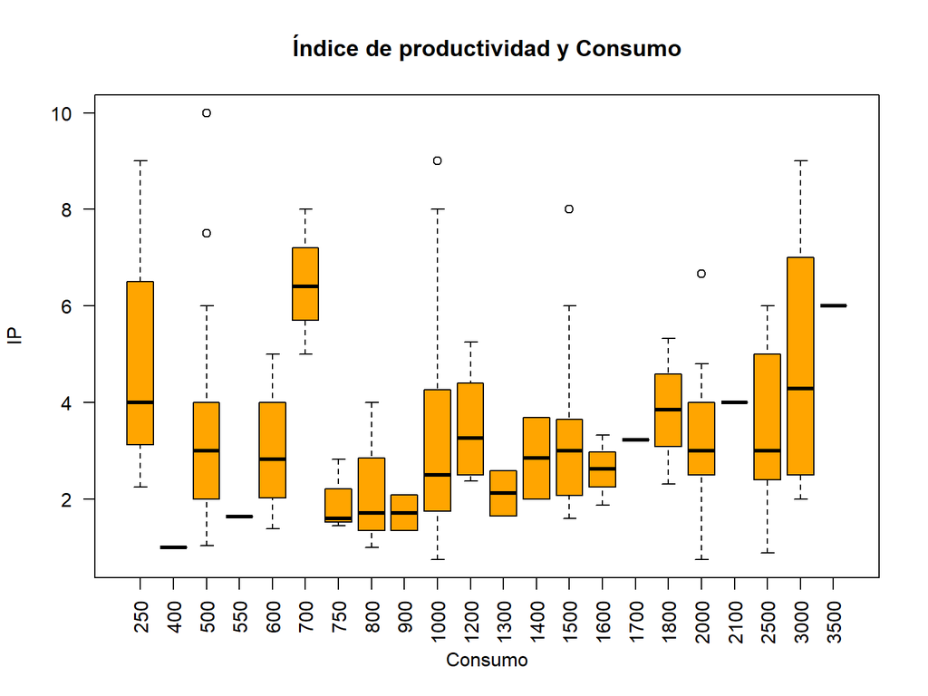

# **Analisis descriptivo**

### Objetivo 2:

- Observar de que si hay mayores intervalos de consumo de agua en el día, entonces se produciría una fatiga y reduce su productividad.

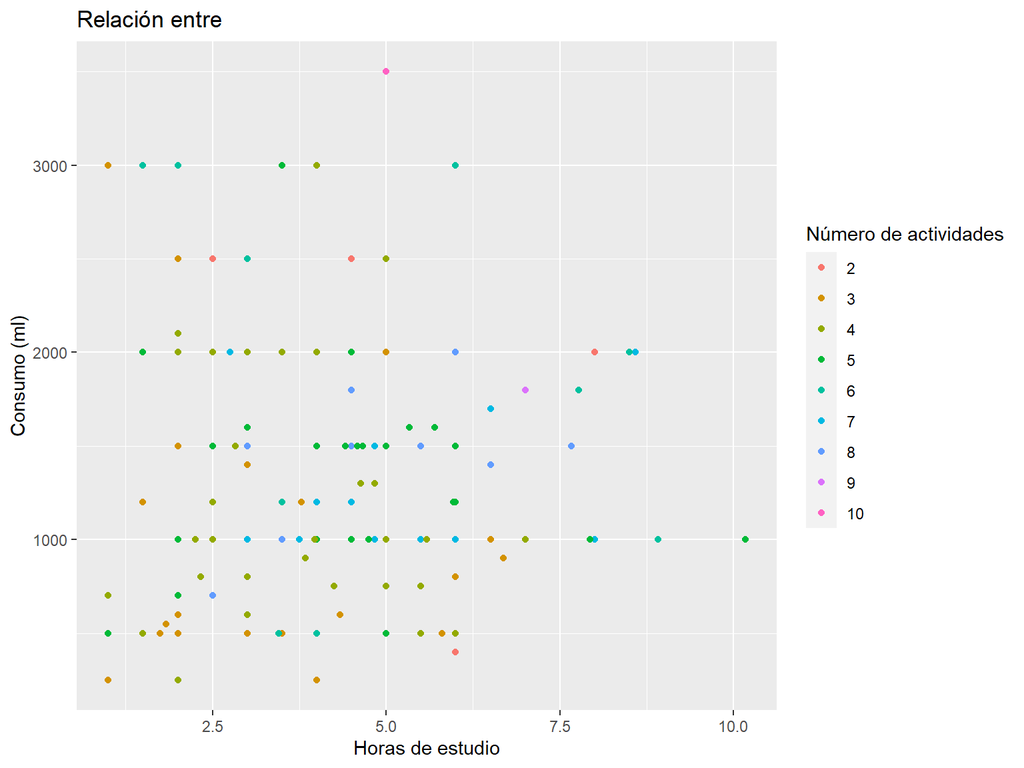

# **Analisis probabilístico**

### *Probabilidad empírica*

Variables a utilizar :

- Primer Variable = Sexo

##### Recapitulamos las probabilidades que tenemos

Probabilidades empíricas de la **variable Sexo**

$$P(A) = P(S_m) = 0.5337079$$

$$P(A^c) = P(S_f) = 0.4662921$$

- Segundo Variable = Consumo
- Probabilidades empíricas de los *eventos compuestos* obtenidos de la variable Consumo

$$P(B) = P(C_1) = 0.7022472$$

$$P(B^c) = P(C_1^c) =
0.2977528$$

# **Analisis probabilístico**

*SE BUSCA DETERMINAR SI EL PAR DE VARIABLES ESCOGIDOS SON DEPENDIENTES O INDEPENDIENTES*

*SI DOS VARIABLEs son INDEPENDIENTES se debe cumplir que:*

$$P(A|B) = P(A)$$
$$P(B|A) = P(B)$$
Comprobamos :

$$P(A|B) = \frac{P(A \cap B)}{P(B)} =
\frac{P(S_m \cap C_1)}{P(C_1)} = 0.3876404/0.7022472 = 0.5519999$$
Entonces :

$$P(A|B) = 0.5519999$$
Asignación de valor a las variables

```r
prob_AB <- 0.3876404/0.7022472
prob_A <- 0.5337079
prob_B <- 0.7022472
```

##### Entonces anunciamos si existe una condicional:

```r
if(prob_AB == prob_A*prob_B){
  print("Los eventos A y B son independientes")
}else {
  print("Los eventos A y B son dependientes")
}
```

```
## [1] "Los eventos A y B son dependientes"
```

# **Analisis probabilístico**

### *Variables aleatorias Discretas*

#### Variable estudiada *Número de actividades*

Para este caso, primero definiremos la distribución que usaremos para esta variable.

La probabilidad del éxito en nuestra base de datos es de: 0.47

X ~ Número de estudiantes del periodo 2023_I de la UTEC que se caracterizan por ser productivos, aquellos que son considerados de ese modo son los que realizan un número de actividades mayor o igual a 5, cabe señalar que nos referimos a actividades al día relacionadas a lo académico, en una muestra de 25 estudiantes.

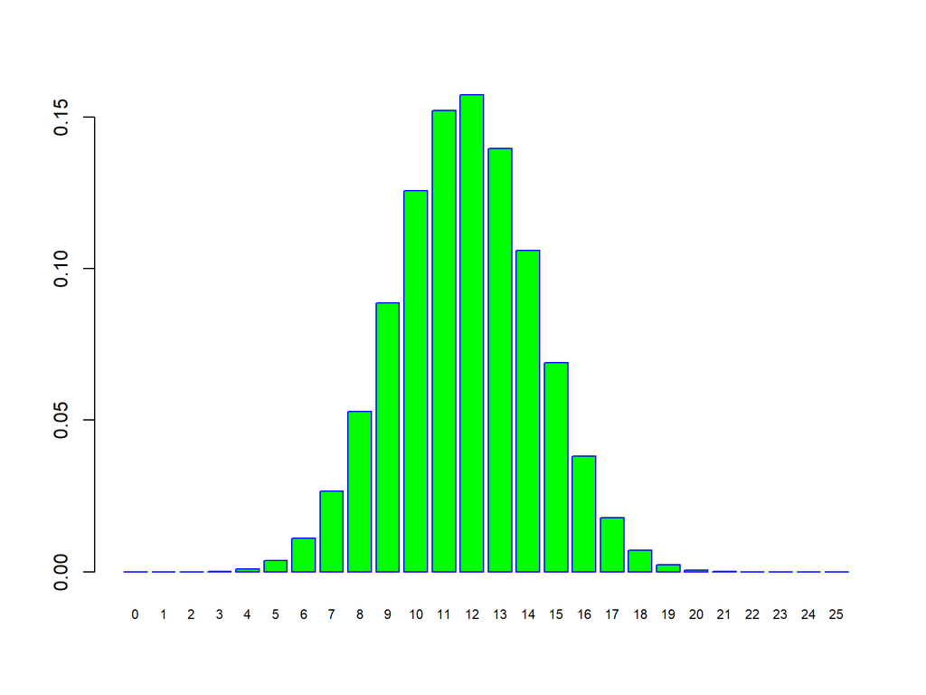

```r
X <- c(0:25)

grafica <- dbinom(X,25,0.47)

barplot(grafica, col = "green", border = "blue", names.arg = c(0:25), cex.names = 0.7)
```

###### Para **Distribución binomial negativa (Pascal)**

La probabilidad del éxito en nuestra base de datos es de:0.69

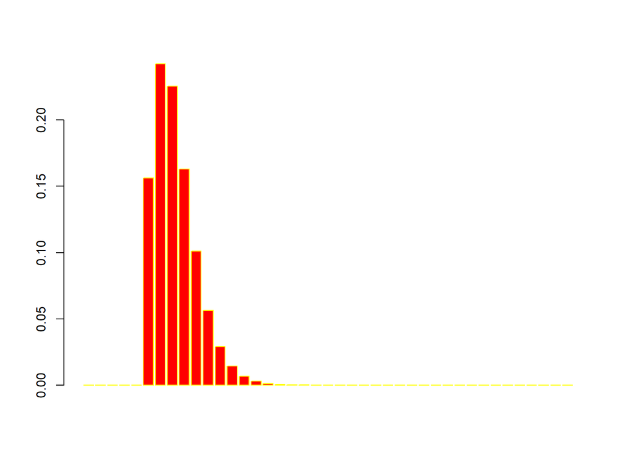

## **Analisis probabilístico**

### *Variables aleatorias Continuas*

##### Variable estudiada *Índice de productividad IP*

**Identificar graficamente**

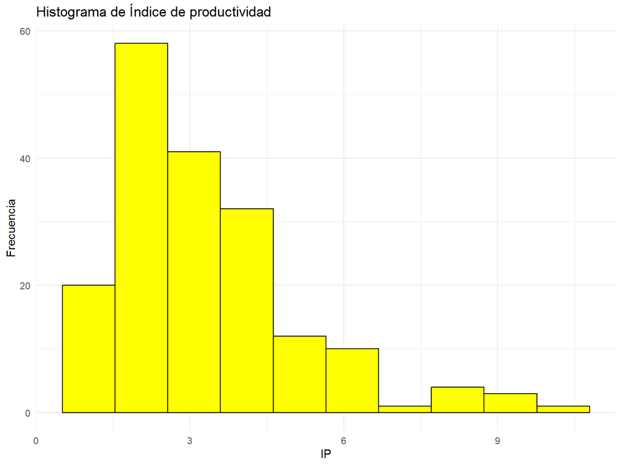

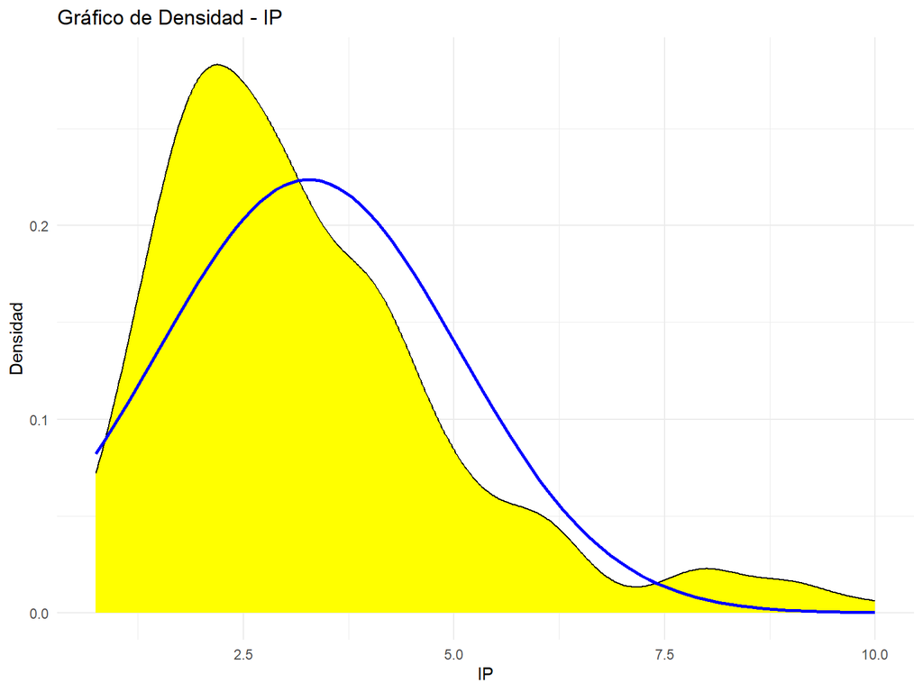

```r
# Densidad IP
ggplot(RF_LIMPIO, aes(x = IP)) +
  geom_density(fill = "yellow", color = "black") +
  labs(x = "IP", y = "Densidad", title = "Gráfico de Densidad - IP") +
  theme_minimal() +
  stat_function(fun = dnorm, args = list(mean = mean(RF_LIMPIO$IP), sd = sd(RF_LIMPIO$IP)), color = "blue", linewidth = 1)
```

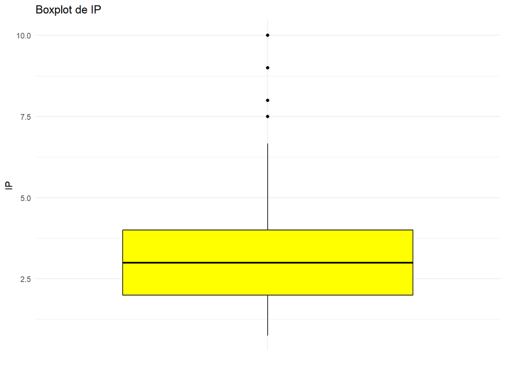

```r
# Boxplot IP
ggplot(RF_LIMPIO, aes(x = "", y = IP)) +
  geom_boxplot(fill = "yellow", color = "black") +
  labs(x = "", y = "IP", title = "Boxplot de IP") +
  theme_minimal()
```

La mediana es de: 3

##### Variable estudiada *Consumo*

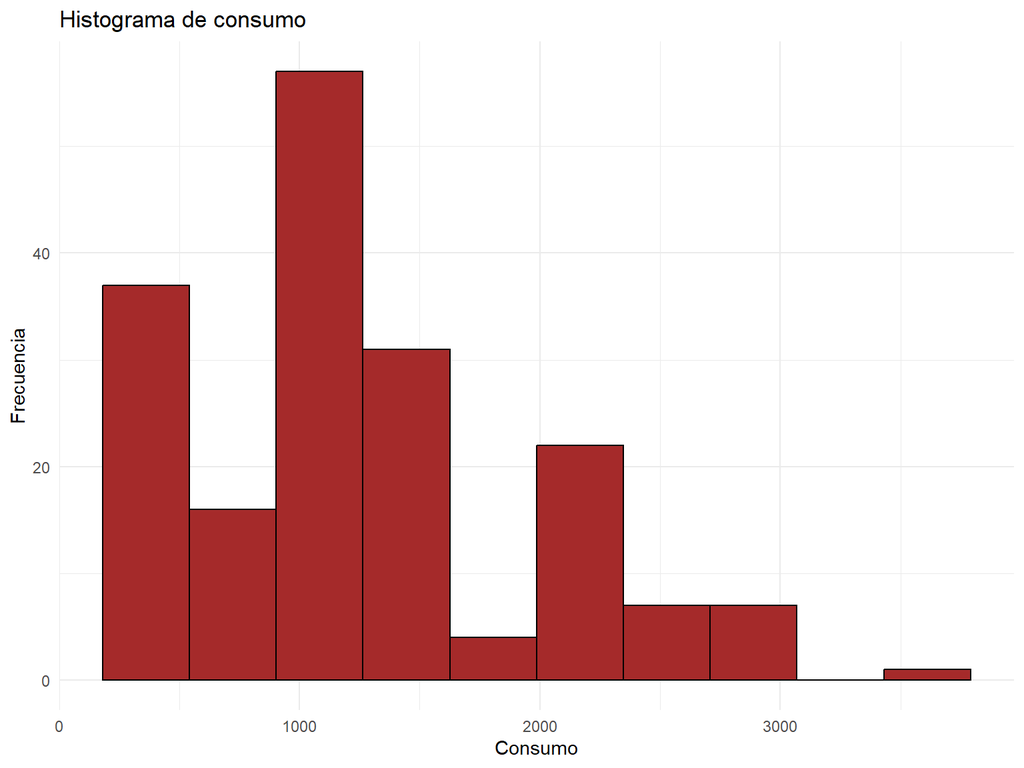

[figure not shown]

[figure not shown]

```r
# Histograma de la variable consumo
ggplot(RF_LIMPIO, aes(x = Consumo)) +
  geom_histogram(color = "black", fill = "brown", bins = 10) +
  labs(x = "Consumo", y = "Frecuencia", title = "Histograma de consumo") +
  theme_minimal()
```

La media es de: 1248.08

La mediana es de: 1000

# **CONCLUSIONES**

- Primero, se logró con el objetivo general de investigar y analizar la relación entre la hidratación y el rendimiento/productividad en los alumnos de la UTEC.